# Why You Shouldn’t Buy a Half Point for Super Bowl 2021.

### Understanding the Question.

In 2021, we have been blessed with the Super Bowl matchup of our dreams, `G.O.A.T. Brady vs. God Mahomes`. The opening line on Bovada is Chiefs -3.5 (+100) and Bucs +3.5 (-120), as shown in the screenshot below.

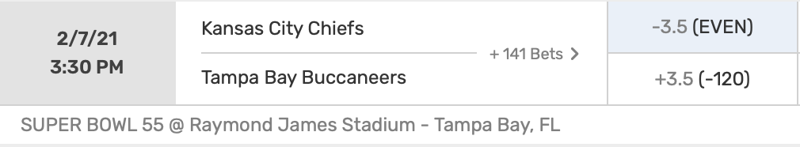

This corresponds to the following profit chart.

|  | Chiefs Cover -3.5 | Bucs Cover +3.5 |
| --- | --- | --- |
| **Bet $\$B$ on Chiefs -3.5 (+100)** | $+B$ | $-B$ |
| **Bet $\$B$ on Bucs +3.5 (-120)** | $-B$ | $+B\cdot\frac{100}{120} = +.83B$ |

I’ll be betting on the Chiefs because clearly they’re the better team, and I’ll take a 25 year-old Mahomes over a 43 year-old Brady. However, the -3.5 line gives me pause, because 3 points is the most common margin of victory in the NFL, and I don’t want to lose my bet via the Chiefs’ winning the Super Bowl by 3. So, Bovada provides an alternative option: I can “buy a half point”. In other words, Bovada has an alternative line, Chiefs -3 (-135), as indicated by the screenshot below.

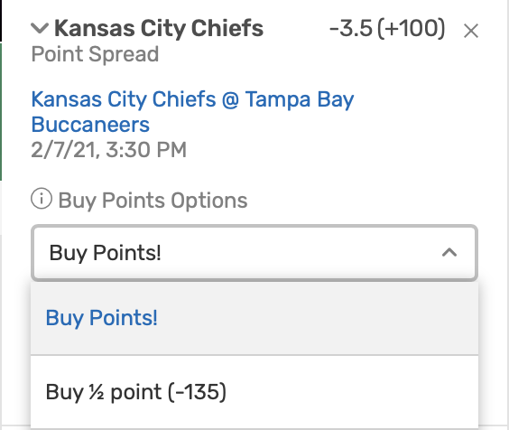

Buying a half point corresponds to the following profit chart.

|  | Chiefs Cover -3 | Bucs Cover +3 | Chiefs win by Exactly 3 |
| --- | --- | --- | --- |
| **Bet $\$B$ on Chiefs -3 (-135)** | $+B\cdot\frac{100}{135} = +.74B$ | $-B$ | $0$ |

So, is it worth it to pay the stiff juice of a $-135$ moneyline to avoid despair if the Chiefs win by a field goal?

### Probability Model.

Let $X_0$ be the random variable denoting the profit from betting $\$B$ on the original $-3.5$ line, and let $X_A$ denote the profit from betting $\$B$ on the alternative $-3$ line. So,

$$X_0 = \begin{cases}
+B & \text{if Chiefs win by } \geq 4 \\
-B & \text{else} \\
\end{cases}$$

$$X_A = \begin{cases}
+\frac{100}{135}B & \text{if Chiefs win by } \geq 4 \\
0 & \text{if Chiefs win by exactly } 3 \\
-B & \text{else}. \\
\end{cases}$$

To make the model more explicit, we introduce 2 parameters. Let $p$ denote the probability that the Chiefs win by $\geq 4$ points, and let $q$ denote the probability that the Chiefs win by exactly $3$ points. Then

$$X_0 = \begin{cases}
+B & \text{with probability } p \\
-B & \text{with probability } 1-p
\end{cases}$$

$$X_A = \begin{cases}
+\frac{100}{135}B & \text{with probability } p \\
0 & \text{with probability } q \\
-B & \text{with probability } 1-p-q. \\
\end{cases}$$

A strategy is more profitable if it has a higher expected profit. In other words, we buy a half point if and only if

$$\mathbb{E}X_A - \mathbb{E}X_0 > 0.$$

Well,

$$\begin{aligned}
\mathbb{E}X_A - \mathbb{E}X_0 &= \bigg(B\frac{100}{135}p - B(1-p-q)\bigg) - \bigg(Bp - B(1-p)\bigg) \\
&= B\bigg((\frac{235}{135}p + q - 1) - (2p-1) \bigg) \\
&= B\bigg(q - \frac{35}{135}p \bigg) \\
&= B\bigg(q - \frac{7}{27}p \bigg). \\
\end{aligned}$$

Therefore, we buy a half point if and only if $\mathbb{E}X_A - \mathbb{E}X_0 > 0$, iff

$$q > \frac{7}{27}p.$$

Hence we need only calculate $p$ and $q$.

### Estimating $p$ and $q$.

Given that the Chiefs are a $3.5$ point favorite, $p$ is the probability that the Chiefs win by $\geq 4$ points, and $q$ is the probability that the Chiefs win by exactly $3$ points. Our task is to estimate $p$ and $q$.

I found a dataset containing the opening and closing pointspreads from every NFL game during the last 10 years, ending with NFL Week 14, 2020. Here is a peak at the head of the dataset, showing the some of the Week 14 results.

```
        date away.team home.team away.score home.score home.line.open home.line.close
1 2020-12-14    Ravens    Browns         47         42            1.0             3.0
2 2020-12-13  Steelers     Bills         15         26            2.0            -2.0
3 2020-12-13   Falcons  Chargers         17         20            2.5            -1.0
4 2020-12-13    Saints    Eagles         21         24            7.0             7.5
```

Now, we narrow the dataset to include only the games that had an opening or closing pointspread of $3.5$. Then, we modify the dataset to include 2 new columns: `fave.covers`, which is `TRUE` iff the favorite covered the $-3.5$ spread, and `exactly.3`, which is `TRUE` iff the final score ended in the favorite winning by exactly 3 points. Here is a peak at the head of the updated dataset.

```
          date away.team  home.team away.score home.score home.line.open home.line.close fave.covers exactly.3
1   2020-12-13   Broncos   Panthers         32         27           -3.5            -4.0       FALSE     FALSE
286 2020-12-06     Colts     Texans         26         20            2.5             3.5        TRUE     FALSE
2   2020-12-06    Browns     Titans         41         35           -4.0            -3.5       FALSE     FALSE
3   2020-12-02    Ravens   Steelers         14         19           -3.5            -5.0        TRUE     FALSE
287 2020-11-29    Chiefs Buccaneers         27         24            3.5             3.5       FALSE      TRUE
4   2020-11-23      Rams Buccaneers         27         24           -3.5            -4.5       FALSE     FALSE
```

Interestingly, as shown above, the Chiefs and Bucs met earlier in the season, on November 29, 2020. The Chiefs were also $3.5$ point favorites then, and they won by exactly 3 points! Spooky!

Now, we estimate $p$, the probability that a $-3.5$ point favorite covers the spread, and $q$, the probability that a $-3.5$ point favorite wins by exactly 3 points, by the empirical proportions from our dataset. Hence

$$p = 0.48$$

and

$$q = 0.08.$$

Finally, note that our dataset of games having a pointspread of $3.5$ contains $463$ games, which is a nice sample size, enough to give us some confidence in our estimates for $p$ and $q$.

### Conclusion.

As calculated previously,

$$\mathbb{E}X_A - \mathbb{E}X_0 = B\bigg(q - \frac{7}{27}p \bigg).$$

We just calculated $p = 0.48$ and $q = 0.08$. Furthermore, during each week of the 2020 NFL season, Ryan Brill and his buddy Nick Miller made $\$ 50$ worth of NFL bets on the [Bet, Sweat, and Forget Podcast](https://ryansbrill.com/bsf/), so we shall use a bet size of $B =50$. Hence

$$\mathbb{E}X_A - \mathbb{E}X_0 = -2.22.$$

Since $\mathbb{E}X_A - \mathbb{E}X_0 < 0$, it is more profitable on average *not* to buy a half point, no matter how tempting it may seem!

### More General Moneylines.

More generally, we suppose that the original pointspread has a moneyline of $-M_0$ for the favorite and that the alternative “buy a half point” pointspread has a moneyline of $-M_A$ for the favorite. Suppose we bet $\$ B$. Let $p$ be the probability that the favorite covers in the original bet, and let $q$ be the probability that the final game score is exactly the pointspread in the alternative bet. Then the profit $X_0$ of betting on the original pointspread, and the profit $X_A$ of betting on the alternative pointspread, are given by

$$X_0 = \begin{cases}
+B\frac{100}{M_0} & \text{with probability } p \\
-B & \text{with probability } 1-p
\end{cases}$$

$$X_A = \begin{cases}
+B\frac{100}{M_A} & \text{with probability } p \\
0 & \text{with probability } q \\
-B & \text{with probability } 1-p-q. \\
\end{cases}$$

Therefore,

$$\begin{aligned}
\mathbb{E}X_A - \mathbb{E}X_0
&= \bigg[B\frac{100}{M_A} p -B (1-p-q)\bigg] - \bigg[ B\frac{100}{M_0} p - B (1-p) \bigg] \\
&= B \bigg[p \bigg(\frac{100}{M_A} - \frac{100}{M_0} \bigg)+ q \bigg].
\end{aligned}$$

Buying a half point is profitable if and only if $\mathbb{E}X_A - \mathbb{E}X_0 > 0$.